# ERCC QC

Szi Kay Leung

2024-12-04

This is a QC report of the ERCC standards added into the sequencing run.

## Detection quality

Number of ERCC reads per sample

| sample | Number of ERCC reads | Number of ERCC molecules |
| --- | --- | --- |
| BC14 | 1332959 | 76 |
| BC15 | 310737 | 73 |

Across the 92 ERCC molecules, a total of 81 (88.04%) were detected. We expect that the ERCC detected would depend on the amount and not on the length i.e. ERCC with the known higher amounts are more likely to be sequenced, whereas longer ERCC are as likely to be sequenced as the shorter ERCC molecules. We also expect this phenomenon to be consistent across all the samples.

### Factors impacting detection

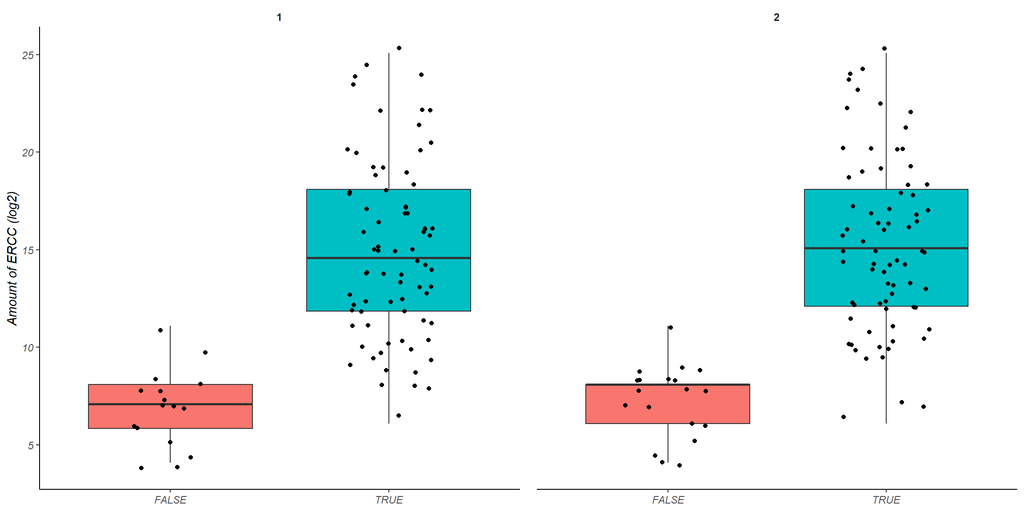

Figure: box-plot of the ERCC detected by amount.

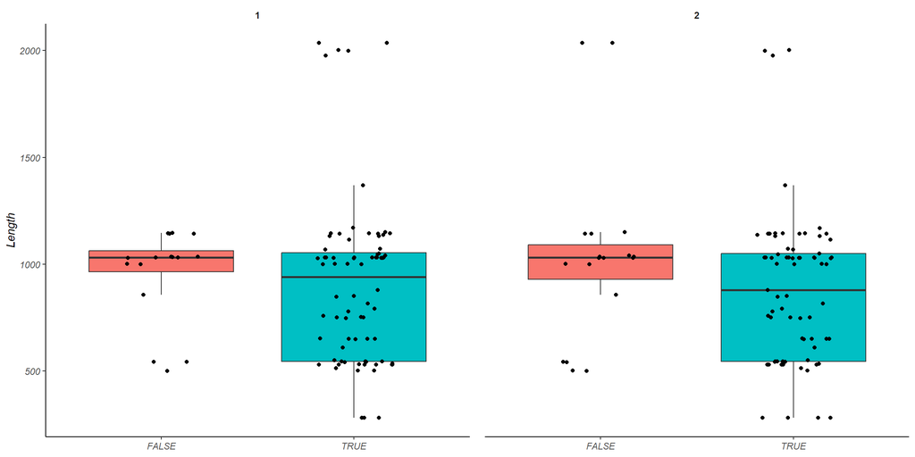

Figure: box-plot of the ERCC detected by length.

### Detection accuracy

#### Number of isoforms collapsed

Following a similar bioinformatics pipeline, aligned ERCC reads are collapsed into unique isoforms and characterised using *SQANTI*. In theory, we should only detect one *isoform* per ERCC molecule. However, in practice, we may detect multiple *isoforms* annotated to the same ERCC molecule due to degradation and shearing during the library preparation.

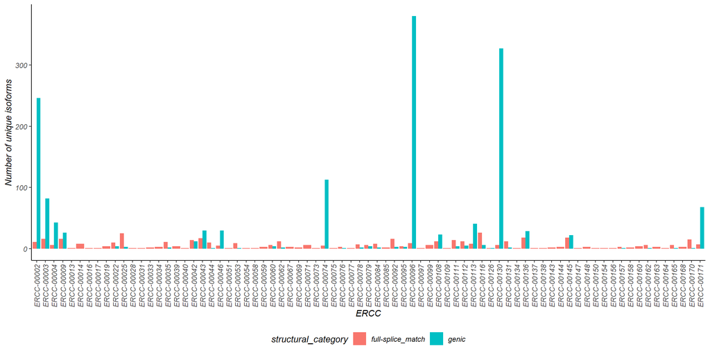

Figure: The number of unique isoforms detected per ERCC molecule, coloured by sqanti structural categories

Notably, the number of *unique isoforms* detected per ERCC molecule is depending on the initial known amounts i.e. the higher the amount of that specific ERCC molecule, the more likely it is to be PCR amplified and sequenced.

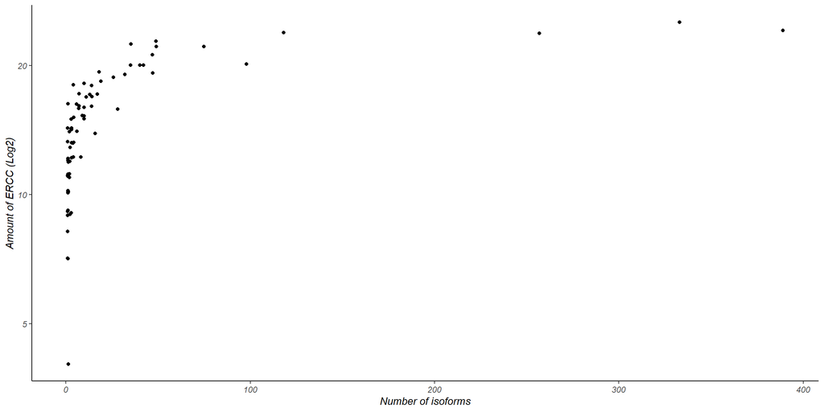

#### Isoform proportions

Despite the significant number of *unique isoforms*, there should only be one or two **dominant** isoform per ERCC molecule whereby the remaining isoforms are insignficant - i.e. a *minor* isoform, defined by less than 5% of the total proportion.

Below are plots of the *isoform* landscape of each ERCC molecule per sample.

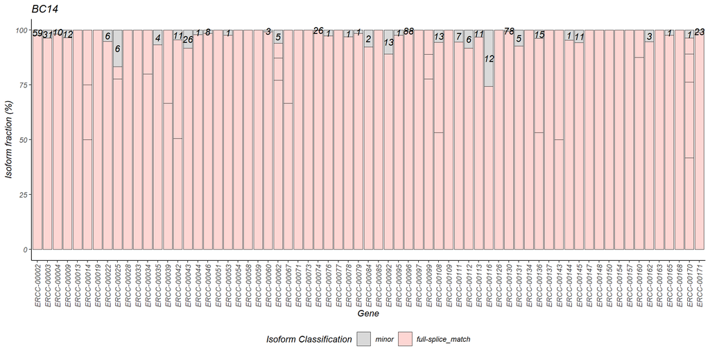

Figure: bar plots of the isoform usage across each ERCC molecule

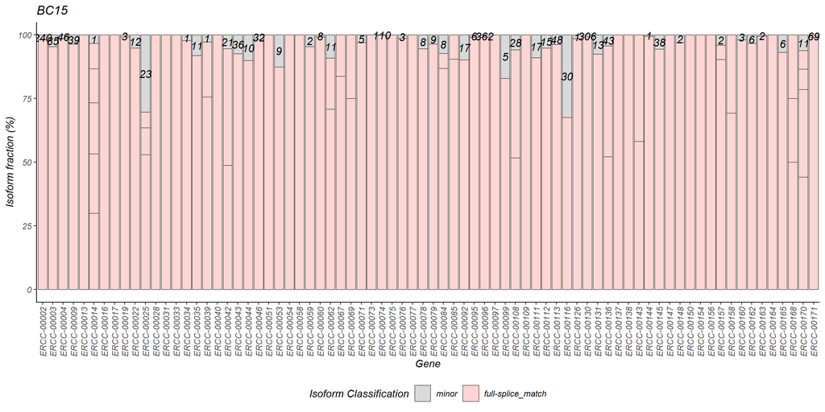

Figure: bar plots of the isoform usage across each ERCC molecule

|  | sample | ERCC | Isoform fraction (%) | Isoform | Number of isoforms |
| --- | --- | --- | --- | --- | --- |
| 1 | BC14 | ERCC-00002 | 97.6923076923077 | PB.1.1 | 1 |
| 2 | BC14 | ERCC-00003 | 96.35016465422612 | PB.2.1 | 1 |
| 3 | BC14 | ERCC-00004 | 98.27650111193476 | PB.3.1 | 1 |
| 4 | BC14 | ERCC-00009 | 96.55430711610487 | PB.4.1 | 1 |
| 5 | BC14 | ERCC-00013 | 100 | PB.5.1 | 1 |
| 6 | BC14 | ERCC-00014 | 50 | PB.6.6 | 3 |
| 7 | BC14 | ERCC-00014 | 25 | PB.6.1 | 3 |
| 8 | BC14 | ERCC-00014 | 25 | PB.6.2 | 3 |
| 9 | BC14 | ERCC-00019 | 100 | PB.9.1 | 1 |
| 10 | BC14 | ERCC-00022 | 94.88372093023256 | PB.10.1 | 1 |

[output cut: 174 more lines]